Group Name - Group 166  
Student Name - Akshat Vijayvargia  
Student ID - s3826627

# Evaluating Credit Card Data

## Introduction

### Data Source

The dataset is taken from Kaggle Repository at https://www.kaggle.com/sakshigoyal7/credit-card-customers.

Credit Card Customers.(2020).BankChurners [Data File]. Retrieved from https://www.kaggle.com/sakshigoyal7/credit-card-customers

### Dataset Details

I will use Credit Card Customers dataset from Kaggle Repository for this project and there is only one csv file named BankChurners.csv. In this dataset, each row represents customer with unique ID and each column contains features or attributes of customers. The dataset is about credit card services of a bank, and purpose of it is to predict and to know the disappointed customers and to act proactively upon it.

### Table

| Serial Number | Name Of Features | Datatype | Units | Brief Description |
| --- | --- | --- | --- | --- |
| 1 | Attrition Flag | object | - | Existing Customer, Attrited Customer |
| 2 | Customer Age | int64 | - | Ages are in 26 to 73 bracket |
| 3 | Gender | object | - | Defines Male or Female |
| 4 | Dependent count | int64 | - | Number of dependents on an individual, is between 0 and 5. |
| 5 | Education Level | object | Unknown | College, Doctorate, Graduate, High School, Post Graduate, Uneducated, Unknown |
| 6 | Marital Status | object | Unknown | Whether an individual is Divorced, Married, Single, Unknown |
| 7 | Income Category | object | Unknown | Defines income bracket-+120k, 40k-60k, 60k-80k,80k-120k,<40k, Unknown |
| 8 | Card Category | object | - | Types of card-Blue, Gold, Platinum, Silver |
| 9 | Avg_Utilization_Ratio | float64 | - | Mean of utilization ratio of customers |

### Target Feature

Our target feature is Customer_Age, which is a continuous feature.

## Goals and Objectives

Our objective is to investigate the dataset and gain insights for better understanding the business situations.

## Data Cleaning and Preprocessing

### Importing Dataset and Loading Required library

```python
# Loading modules
import warnings
warnings.filterwarnings("ignore")
import pandas as pd
import numpy as np
import seaborn as sb
import matplotlib.pyplot as matplt
import requests
###
warnings.filterwarnings('ignore')
###
%matplotlib inline
%config InlineBackend.figure_format = 'retina'
matplt.style.use("ggplot")

# Importing the dataset
pd.set_option('display.max_columns',None)
dataframe=pd.read_csv(r"C:/Users/61422/Desktop/Data_Group166.csv")

# Looking at randomly selected 5000 rows
dataframe2=dataframe.sample(5000, random_state=999)
```

### Dropping Irrelevant Columns

```python
dataframe2.drop(dataframe.columns[[0, 9,10,11,12,13,14,15,16,17,18,19,21,22]], axis = 1, inplace = True)
dataframe2
```

|  | Attrition_Flag | Customer_Age | Gender | Dependent_count | Education_Level | Marital_Status | Income_Category | Card_Category | Avg_Utilization_Ratio |
| --- | --- | --- | --- | --- | --- | --- | --- | --- | --- |
| 1342 | Existing Customer | 52 | M | 2 | Uneducated | Single | $80K - $120K | Blue | 0.069 |
| 6490 | Existing Customer | 49 | F | 3 | Uneducated | Married | Less than $40K | Blue | 0.370 |
| 2526 | Existing Customer | 36 | F | 3 | Graduate | Single | Unknown | Blue | 0.069 |
| 9599 | Attrited Customer | 34 | M | 3 | Post-Graduate | Single | $40K - $60K | Blue | 0.000 |
| 8193 | Existing Customer | 52 | M | 3 | Graduate | Single | $80K - $120K | Blue | 0.000 |
| ... | ... | ... | ... | ... | ... | ... | ... | ... | ... |
| 8494 | Existing Customer | 48 | F | 3 | Unknown | Single | Less than $40K | Blue | 0.509 |
| 7735 | Existing Customer | 34 | F | 0 | Graduate | Married | $40K - $60K | Blue | 0.612 |
| 9046 | Existing Customer | 44 | F | 4 | Uneducated | Married | Less than $40K | Blue | 0.167 |
| 3805 | Existing Customer | 46 | F | 3 | Graduate | Unknown | Less than $40K | Blue | 0.324 |
| 9253 | Existing Customer | 41 | F | 3 | Doctorate | Married | $40K - $60K | Silver | 0.045 |

5000 rows × 9 columns

### Checking for missing values and unique values in our sampled dataset

```python
# Lets have a look at the datatypes of features
dataframe2.info()
```

```
<class 'pandas.core.frame.DataFrame'>
Int64Index: 5000 entries, 1342 to 9253
Data columns (total 9 columns):
 #   Column                 Non-Null Count  Dtype
---  ------                 --------------  -----
 0   Attrition_Flag         5000 non-null   object
 1   Customer_Age           5000 non-null   int64
 2   Gender                 5000 non-null   object
 3   Dependent_count        5000 non-null   int64
 4   Education_Level        5000 non-null   object
 5   Marital_Status         5000 non-null   object
 6   Income_Category        5000 non-null   object
 7   Card_Category          5000 non-null   object
 8   Avg_Utilization_Ratio  5000 non-null   float64
dtypes: float64(1), int64(2), object(6)
memory usage: 390.6+ KB
```

```python
# Checking missing values through isna() function
print('Number of missing values in each column are-')
print(dataframe2.isna().sum())
```

```
Number of missing values in each column are-
Attrition_Flag           0
Customer_Age             0
Gender                   0
Dependent_count          0
Education_Level          0
Marital_Status           0
Income_Category          0
Card_Category            0
Avg_Utilization_Ratio    0
dtype: int64
```

```python
# Checking the unique values of our dataset
cat_cols=dataframe2.columns[dataframe2.dtypes==object].tolist()
cat_cols
```

```
['Attrition_Flag',
 'Gender',
 'Education_Level',
 'Marital_Status',
 'Income_Category',
 'Card_Category']
```

```python
for col in cat_cols:
    print('Unique values in ' + col + ' are-')
    print(dataframe2[col].unique())
    print('')
```

```
Unique values in Attrition_Flag are-
['Existing Customer' 'Attrited Customer']

Unique values in Gender are-
['M' 'F']

Unique values in Education_Level are-
['Uneducated' 'Graduate' 'Post-Graduate' 'High School' 'Unknown' 'College'
 'Doctorate']

Unique values in Marital_Status are-
['Single' 'Married' 'Unknown' 'Divorced']

Unique values in Income_Category are-
['$80K - $120K' 'Less than $40K' 'Unknown' '$40K - $60K' '$60K - $80K'
 '$120K +']

Unique values in Card_Category are-
['Blue' 'Silver' 'Gold' 'Platinum']
```

### Checking Outliers

Outliers are the values, which stand far away from central tendencies.

Let's check the outliers of Customer_Age feature.

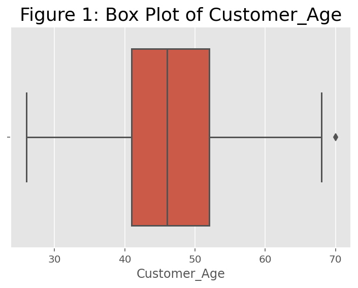

```python
sb.boxplot(dataframe2['Customer_Age']).set_title('Figure 1: Box Plot of Customer_Age', fontsize = 18)
matplt.show();
```

There is one outlier, but we wont drop the rows as having the age of 70 is reasonable and it would not affect our working.

Now, check the outliers of Dependent_Count

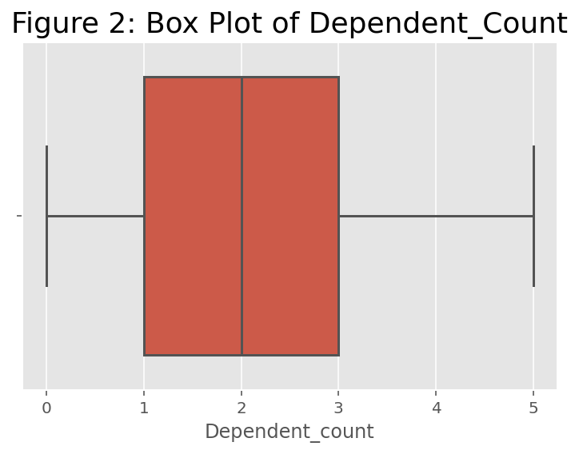

```python
sb.boxplot(dataframe2['Dependent_count']).set_title('Figure 2: Box Plot of Dependent_Count', fontsize = 18)
matplt.show();
```

There are no outliers in the numeric feature Dependent_count.

### Summary Statistics Of Numeric Features

```python
from IPython.display import display, HTML
display(HTML('<b>Table 1: Summary Statistics of Numeric Features</b>'))
dataframe2.describe(include='int64')
```

**Table 1: Summary Statistics of Numeric Features**

|  | Customer_Age | Dependent_count |
| --- | --- | --- |
| count | 5000.000000 | 5000.00000 |
| mean | 46.236400 | 2.35540 |
| std | 8.003632 | 1.29824 |
| min | 26.000000 | 0.00000 |
| 25% | 41.000000 | 1.00000 |
| 50% | 46.000000 | 2.00000 |
| 75% | 52.000000 | 3.00000 |
| max | 70.000000 | 5.00000 |

### Summary Statistics Of Categorical Features

```python
display(HTML('<b>Table 1: Summary Statistics of Categorical Features</b>'))
dataframe2.describe(include='object')
```

**Table 1: Summary Statistics of Categorical Features**

|  | Attrition_Flag | Gender | Education_Level | Marital_Status | Income_Category | Card_Category |
| --- | --- | --- | --- | --- | --- | --- |
| count | 5000 | 5000 | 5000 | 5000 | 5000 | 5000 |
| unique | 2 | 2 | 7 | 4 | 6 | 4 |
| top | Existing Customer | F | Graduate | Married | Less than $40K | Blue |
| freq | 4186 | 2653 | 1551 | 2323 | 1769 | 4657 |

### Summary Statistics Of Float Feature

```python
display(HTML('<b>Table 1: Summary Statistics of Categorical Features</b>'))
dataframe2.describe(include='float64')
```

|  | Avg_Utilization_Ratio |
| --- | --- |
| count | 5000.000000 |
| mean | 0.274816 |
| std | 0.276250 |
| min | 0.000000 |
| 25% | 0.022000 |
| 50% | 0.174500 |
| 75% | 0.504250 |
| max | 0.994000 |

## Data Exploration and Visualization

This is a step, where we can actually play with our dataset as before we only cleanse it to to its level.

### Univariate Visualization

Let's visualize the customer based on their income brackets.

**Figure 3: Bar Chart Of Income Category**

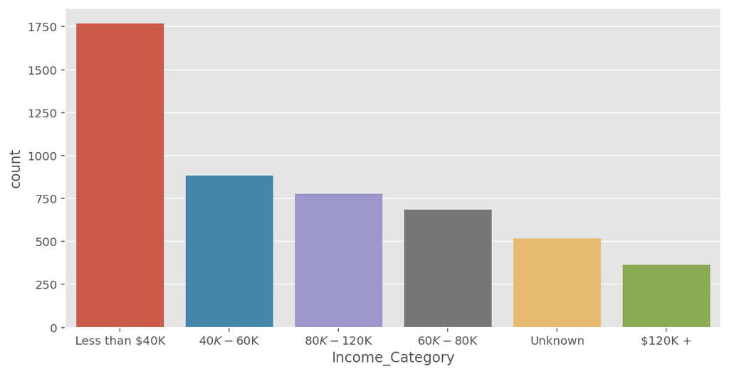

```python
display(HTML('<b>Figure 3: Bar Chart Of Income Category</b>'))
matplt.figure(figsize = (10, 5))
sb.countplot(x = 'Income_Category',data = dataframe2,order = dataframe2['Income_Category'].value_counts().index)
matplt.show();
```

From Figure 3, we can say that most of our customers are from less than 40k bracket, then followed by 40k-60k and 80k-120k bracket respectively.

Now will have a look on Bar Plot of Gender.

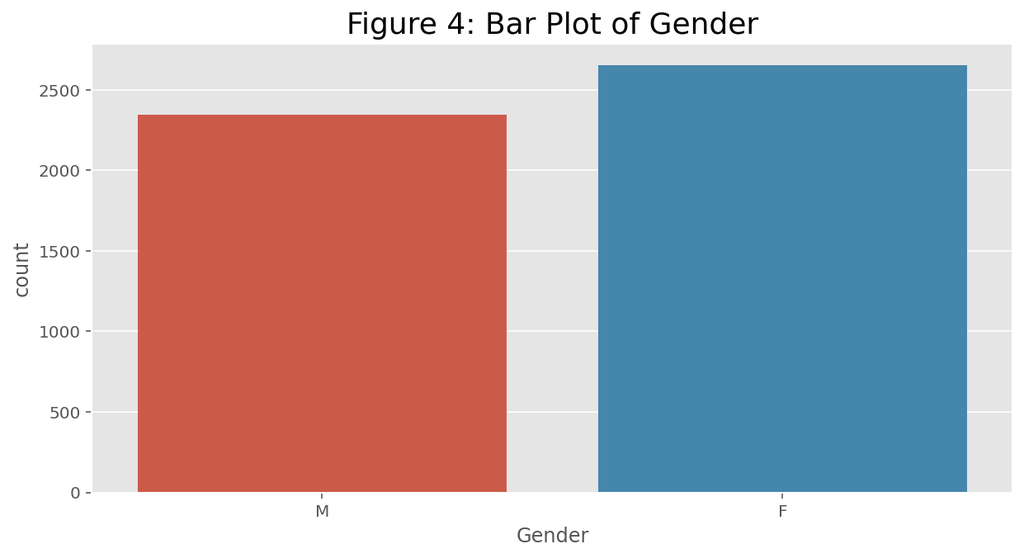

```python
matplt.figure(figsize = (10, 5))
sb.countplot(dataframe2['Gender']).set_title('Figure 4: Bar Plot of Gender', fontsize = 18)
matplt.show();
```

From Figure 4, we can deduce that our clientele is dominated by female customers than the male customers. The number of female customers add upto around 2700.

### Bivariate Visualizaion

Let's get Bar plot of Attrition_Flag with Gender category.

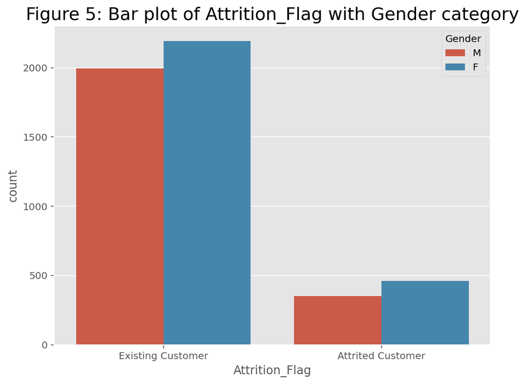

```python
matplt.figure(figsize = (8, 6))
sb.countplot(dataframe2['Attrition_Flag'],hue=dataframe2['Gender']).set_title('Figure 5: Bar plot of Attrition_Flag with Gender category', fontsize = 18)
matplt.show();
```

Figure 5 clearly shows that females are more not only in our customer base but also in attrition list.

After having insights on customer, lets look, which gender uses our our credit card service more.

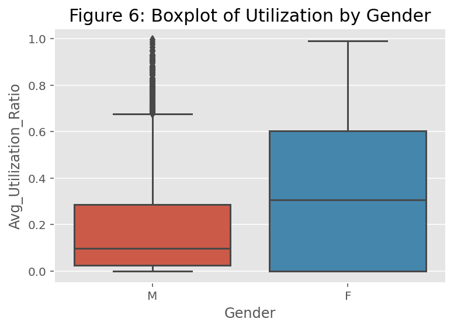

```python
sb.boxplot(dataframe2['Gender'], dataframe2['Avg_Utilization_Ratio']);
matplt.title('Figure 6: Boxplot of Utilization by Gender', fontsize = 15)
matplt.show();
```

From the above box plot, we can easily conclude that customers, who are male has less average utilization ratio. As the female customers are more, there utilization ratio is also more.